# 绘图可视化 (1) matplotlib绘图基础

```python
import matplotlib.pyplot as plt
%matplotlib inline #加这行不需要再写plt.show()
```

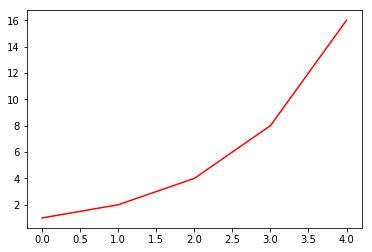

```python
# 折线图，红色
plt.plot([1,2,4,8,16],'r')
```

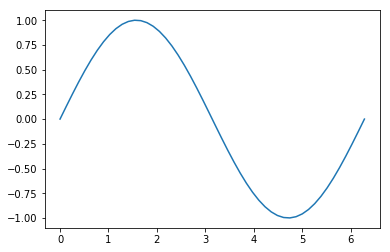

```python
import numpy as np

x=np.linspace(0,2*np.pi)
plt.plot(x,np.sin(x))
```

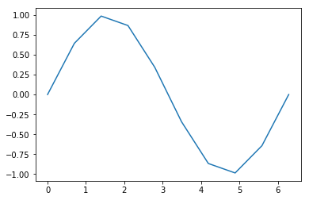

```python
x=np.linspace(0,2*np.pi,10) #包含10个元素，均匀分布在[0,2pi]
plt.plot(x,np.sin(x))
plt.show()
```

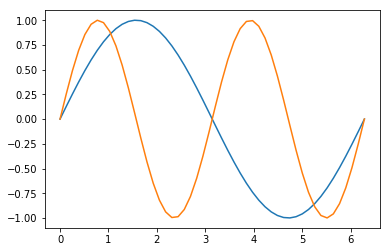

```python
#在一张图中绘制多个数据集
x=np.linspace(0,2*np.pi)
plt.plot(x,np.sin(x),x,np.sin(2*x))
#plt.show()
```

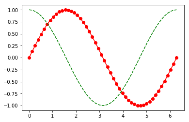

```python
#自定义图形的外观
x=np.linspace(0,2*np.pi)
plt.plot(x,np.sin(x),'r-o',
         x,np.cos(x),'g--')
#plt.show()
```

上述代码展示了两种不同的曲线样式：'r-o' 和 'g--'。字母 'r' 和 'g' 代表线条的颜色，后面的符号代表线和点标记的类型。例如 '-o' 代表包含实心点标记的实线，'--' 代表虚线。

> 颜色： 蓝色 - 'b' 绿色 - 'g' 红色 - 'r' 青色 - 'c' 品红 - 'm' 黄色 - 'y' 黑色 - 'k'（'b'代表蓝色，所以这里用黑色的最后一个字母） 白色 - 'w' 线： 直线 - '-' 虚线 - '--' 点线 - ':' 点划线 - '-.' 常用点标记 点 - '.' 像素 - ',' 圆 - 'o' 方形 - 's' 三角形 - '^'

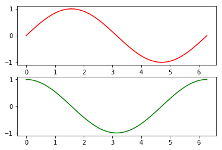

```python
#使用子图可以在一个窗口绘制多张图

x=np.linspace(0,2*np.pi)
plt.subplot(2,1,1) #行，列，活跃区
plt.plot(x,np.sin(x),'r')
plt.subplot(2,1,2)
plt.plot(x,np.cos(x),'g')
#plt.show()
```

活跃区域代表当前子图所在绘图区域，绘图区域是按从左至右，从上至下的顺序编号。例如在 4×4 的方格上，活跃区域 6 在方格上的坐标为 (2, 2)。

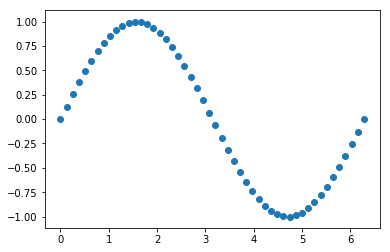

```python
# 简单的散点图
x=np.linspace(0,2*np.pi)
y=np.sin(x)
plt.scatter(x,y)
#plt.show()
```

只需要调用 scatter() 函数并传入两个分别代表 x 坐标和 y 坐标的数组。注意，我们通过 plot 命令并将线的样式设置为 'bo' 也可以实现同样的效果。

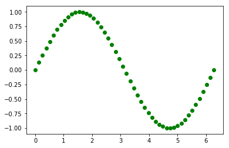

```python
x=np.linspace(0,2*np.pi)
plt.plot(x,np.sin(x),'go')
plt.show()
```

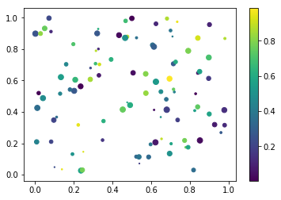

```python
#彩色映射散点图
x=np.random.rand(100)
y=np.random.rand(100)
size=np.random.rand(100)*50
colour=np.random.rand(100)
plt.scatter(x,y,size,colour)
plt.colorbar()
plt.show()
```

同前面一样我们用到了 scatter() 函数，但是这次我们传入了另外的两个参数，分别为所绘点的大小和颜色。通过这种方式使得图上点的大小和颜色根据数据的大小产生变化。

然后我们用 colorbar() 函数添加了一个颜色栏。

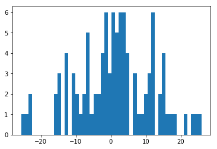

```python
#直方图

x=np.random.randn(100)*10
plt.hist(x,50)
plt.show()
```

直方图是 Matplotlib 中最简单的图形之一。你只需要给 hist() 函数传入一个包含数据的数组。第二个参数代表数据容器的个数。数据容器代表不同的值的间隔，并用来包含我们的数据。数据容器越多，图形上的数据条就越多。

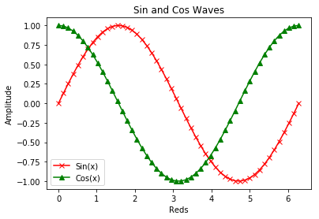

```python
#添加标题，坐标轴标记和图例

x=np.linspace(0,2*np.pi)
plt.plot(x,np.sin(x),'r-x',label='Sin(x)')
plt.plot(x,np.cos(x),'g-^',label='Cos(x)')
plt.legend() #展示图例，必须调用这个上面的label才会显示
plt.xlabel('Reds') #给x轴添加标签
plt.ylabel('Amplitude') #给y轴添加标签
plt.title('Sin and Cos Waves') #添加图形标题
plt.show()
```

为了给图形添加图例，我们需要在 plot() 函数中添加命名参数 'label' 并赋予该参数相应的标签。然后调用 legend() 函数就会在我们的图形中添加图例。

接下来我们只需要调用函数 title()，xlabel() 和 ylabel() 就可以为图形添加标题和标签。

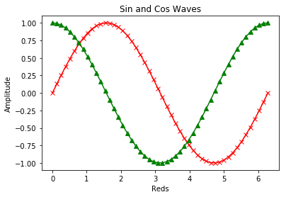

```python
x=np.linspace(0,2*np.pi)
plt.plot(x,np.sin(x),'r-x',label='Sin(x)')
plt.plot(x,np.cos(x),'g-^',label='Cos(x)')
#plt.legend() #展示图例
plt.xlabel('Reds') #给x轴添加标签
plt.ylabel('Amplitude') #给y轴添加标签
plt.title('Sin and Cos Waves') #添加图形标题
plt.show()
```